# outlier제거 및 지역별, 연도별 평단가 분산분석 + 다중회귀분석

Author

2023-2학기 통계자료분석 1조 김재현

Published

December 6, 2023

Modified

December 22, 2023

## 데이터 불러오기 및 변수 정리

```r
# 데이터 불러오기

rawdata = read_excel("./Team_Assignment/Reyeme2.xls")
data1 = as.data.frame(rawdata)
data1$FirstDate = as.Date(as.numeric(as.character(data1$FirstDate)),origin="1899-12-30")
data1$RC = as.factor(data1$RC)
data1$Area = as.factor(data1$Area)
```

```r
# 데이터 변수 클래스 확인

str(data1)
```

```
'data.frame':   456 obs. of  17 variables:
 $ Address  : chr  "73 Allston St" "239 Allston St" "83 Amory St" "107 Antrim St" ...
 $ Unit     : chr  "1" "2" "3" "1" ...
 $ Area     : Factor w/ 16 levels "AG","AH","C",..: 4 4 9 9 9 9 9 9 9 9 ...
 $ AreaCode : num  4 4 9 9 9 9 9 9 9 9 ...
 $ Price1   : num  109000 127000 123000 219000 199000 ...
 $ Price2   : num  109000 127000 100000 210000 189000 ...
 $ SalePrice: num  106000 125000 95000 206000 175000 ...
 $ FirstDate: Date, format: "1993-07-17" "1993-08-21" ...
 $ CloseDate: POSIXct, format: "1993-10-22" "1993-10-22" ...
 $ Days     : num  97 62 208 159 110 116 160 80 157 123 ...
 $ Interior : num  834 850 730 1460 1630 ...
 $ Bed      : num  2 2 2 3 4 2 2 3 3 3 ...
 $ Bath     : num  1 1 1 2 1 1 1 1 1 1 ...
 $ Rooms    : num  4 5 4 6 8 6 6 5 6 6 ...
 $ Condo    : num  70 100 185 100 50 100 100 163 150 100 ...
 $ Tax      : num  490 923 575 1582 1659 ...
 $ RC       : Factor w/ 2 levels "0","1": 1 2 1 2 2 2 2 1 2 2 ...
```

```r
# 결측값 존재 확인

sum(is.na(data1))
```

```
[1] 9
```

**Note**

결측값 9개 존재.

```r
# 결측값 있는 행 확인

which(rowSums(is.na(data1)) > 0)
```

```
[1]  27 181 248 254 350 368 383 454 455
```

**Note**

결측값 중 한개를 제외하곤 모두 UNIT 열 값이다. UNIT는 건물내 특정 주거공간을 나타내는 호수(ex 101호, 102호)이다. Reyem Affiar가 구매하려는 건물의 UNIT는 주어져있지 않기 때문에 Reyem Affiar가 구매하려는 건물 가격을 추정하는데에 UNIT 변수는 사용하지 않을 것으로 예상한다. 나머지 한개의 결측값은 First Date에서 나타났으며, 254행에 있다. FirstDate열은 사용할 예정이므로 254행만 제외한다.

```r
#결측값 있는 행 중 254행 제거

data2 = data1[-254,]
```

```r
# data3 = data2의 Address 열 나누기

data3 <- separate(data2, Address, into = c("AddressNo", "AddressName", "Street"), sep = " ")
data3$AddressNo = as.factor(data3$AddressNo)
data3$AddressName = as.factor(data3$AddressName)
data3$Street = as.factor(data3$Street)
```

```r
#| label: First Date를 연 월 일로 열 나누기
# First Date를 연 월 일로 열 나누기

data4 <- separate(data3, FirstDate, into = c("YearF", "MonthF", "DateF"), sep = "-")
data4$YearF = as.factor(data4$YearF)
data4$MonthF = as.factor(data4$MonthF)
data4$DateF = as.factor(data4$DateF)
```

```r
#| label: 평단가 PrPerI 만들기
# 평단가 PrPerI 만들기

data4$PrPerI = data4$SalePrice/data4$Interior
```

```r
#| label: Bed/Rooms = BedPerR, Bath/Rooms = BathPerR 만들기

# Bed/Rooms = BedPerR, Bath/Rooms = BathPerR 만들기

data4$BedPerR  = data4$Bed/data4$Rooms
data4$BathPerR = data4$Bath/data4$Rooms
```

```r
str(data4)
```

```
'data.frame':   455 obs. of  24 variables:
 $ AddressNo  : Factor w/ 146 levels "1","10","10]",..: 128 57 133 6 8 19 139 97 19 18 ...
 $ AddressName: Factor w/ 112 levels "Allston","Amory",..: 1 1 2 3 3 3 3 3 3 3 ...
 $ Street     : Factor w/ 16 levels "Auburn","Ave",..: 14 14 14 14 14 14 14 14 14 14 ...
 $ Unit       : chr  "1" "2" "3" "1" ...
 $ Area       : Factor w/ 16 levels "AG","AH","C",..: 4 4 9 9 9 9 9 9 9 9 ...
 $ AreaCode   : num  4 4 9 9 9 9 9 9 9 9 ...
 $ Price1     : num  109000 127000 123000 219000 199000 ...
 $ Price2     : num  109000 127000 100000 210000 189000 ...
 $ SalePrice  : num  106000 125000 95000 206000 175000 ...
 $ YearF      : Factor w/ 8 levels "1920","1988",..: 7 7 7 5 6 6 6 7 7 7 ...
 $ MonthF     : Factor w/ 12 levels "01","02","03",..: 7 8 3 3 5 5 8 5 6 9 ...
 $ DateF      : Factor w/ 31 levels "01","02","03",..: 17 21 6 17 28 30 8 18 19 24 ...
 $ CloseDate  : POSIXct, format: "1993-10-22" "1993-10-22" ...
 $ Days       : num  97 62 208 159 110 116 160 80 157 123 ...
 $ Interior   : num  834 850 730 1460 1630 ...
 $ Bed        : num  2 2 2 3 4 2 2 3 3 3 ...
 $ Bath       : num  1 1 1 2 1 1 1 1 1 1 ...
 $ Rooms      : num  4 5 4 6 8 6 6 5 6 6 ...
 $ Condo      : num  70 100 185 100 50 100 100 163 150 100 ...
 $ Tax        : num  490 923 575 1582 1659 ...
 $ RC         : Factor w/ 2 levels "0","1": 1 2 1 2 2 2 2 1 2 2 ...
 $ PrPerI     : num  127 147 130 141 107 ...
 $ BedPerR    : num  0.5 0.4 0.5 0.5 0.5 ...
 $ BathPerR   : num  0.25 0.2 0.25 0.333 0.125 ...
```

## outlier 제거

```r
# data4를 이용한 분산분석 모형 M1(SalePrice ~ Area)
M1 = aov(PrPerI ~ Area, data4)
ri = M1$residuals
```

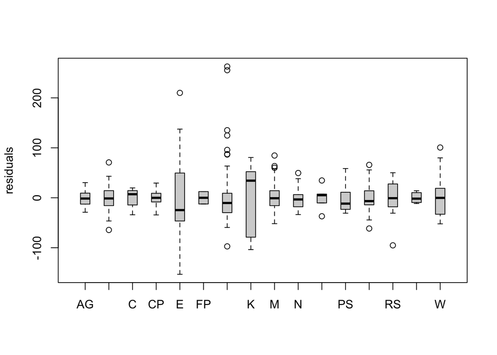

```r
# M1(data4) outlier 확인
ri = M1$residuals
boxplot(ri ~ data4$Area, xlab = "", ylab = "residuals", range= 1.5, boxwex = 0.4) # boxwex는 상자폭을 0.4배 줄이는 옵션
```

```r
# data4의 잔차 ri에서 1.5 IQR을 넘는 극단값 확인
Lo = quantile(ri,0.25)-1.5*IQR(ri)
Up = quantile(ri,0.75)+1.5*IQR(ri)
outliers =ri[(ri<Lo) | (ri>Up)]
outliers
```

```
        51         53         55         57         58         59         60
  82.57763   74.42678   94.26805  137.45936  107.51680   84.29072  209.95649
        69        145        177        178        179        181        310
-123.36234   80.64826  -99.66176 -134.24404 -100.25516  -95.16491   84.60077
       324        326        330        331        332        334        335
 255.39871  262.67673  100.60020   95.77742   79.81188  124.65282   86.56152
       338        342        382        402        407        409        410
 135.23408   87.39039 -153.05070   76.75433 -103.64937  -86.55139  -79.43432
       411        412        432
 -88.13910 -103.02495  -97.22748
```

```r
# ri 극단값의 인덱스 추출 및 제거
outliers_index = which((ri<Lo) | (ri>Up))
outliers_index
```

```
 51  53  55  57  58  59  60  69 145 177 178 179 181 310 324 326 330 331 332 334
 51  53  55  57  58  59  60  69 145 177 178 179 181 309 323 325 329 330 331 333
335 338 342 382 402 407 409 410 411 412 432
334 337 341 381 401 406 408 409 410 411 431
```

```r
data5 = data4[-outliers_index,]
```

31개 데이터 제거

### Days가 너무 긴 혹은 짧은 데이터 삭제

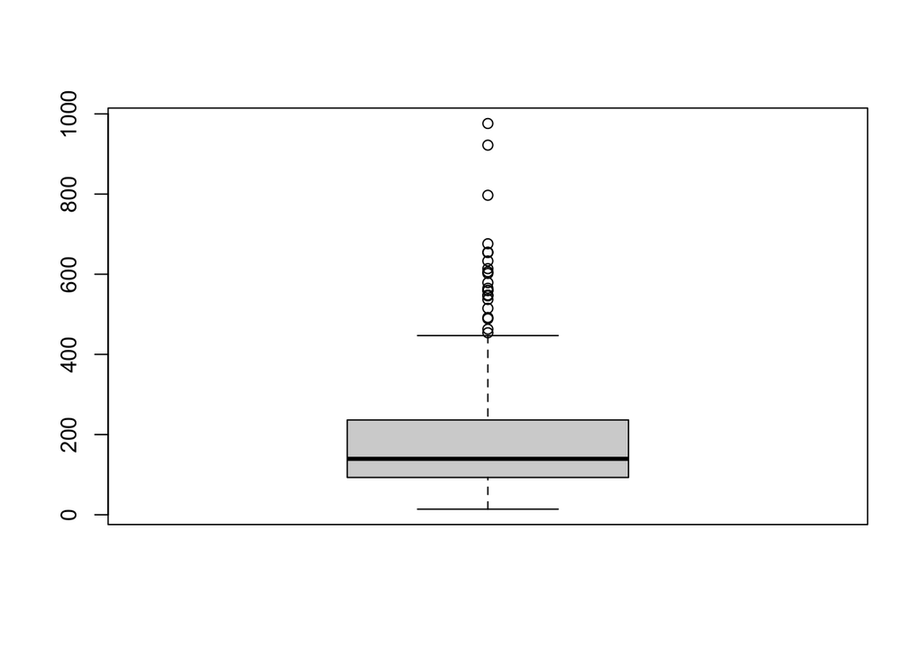

```r
# Days변수의 boxplot 확인
boxplot(data5$Days)
```

```r
# Days변수에서 1.5 IQR을 넘는 극단값 확인
Lo = quantile(data5$Days,0.25)-1.5*IQR(data5$Days)
Up = quantile(data5$Days,0.75)+1.5*IQR(data5$Days)
outliers_days =data5$Days[(data5$Days<Lo) | (data5$Days>Up)]
outliers_days
```

```
 [1] 602 633 515 676 614 579 655 654 546 492 548 559 922 489 976 560 463 797 454
[20] 565 606 537
```

```r
# Days변수 극단값의 인덱스 추출 및 제거(data6)
outliers_days_index = which((data5$Days<Lo) | (data5$Days>Up))
outliers_days_index
```

```
 [1]  11  12  28  34  37  49  57  58 107 140 141 167 191 223 275 282 286 289 315
[20] 316 384 388
```

```r
data6 = data5[-outliers_days_index,]
```

22개 제거

### FirstDate에서 Year가 너무 다른 데이터 삭제

```r
# YearF(FirstDate에서 연도만 추출) factor의 수준 확인
levels(data4$YearF)
```

```
[1] "1920" "1988" "1989" "1990" "1991" "1992" "1993" "1994"
```

```r
# YearF 변수에서 1920년 매매 자료 확인
outliers_YearF = data6$Days[data6$YearF=="1920"]
outliers_YearF
```

```
[1] 113
```

```r
# YearF 변수에서 1920년 매매 자료 제거(data7)
outliers_YearF_index = which(data6$YearF=="1920")
data7 = data6[-outliers_YearF_index,]
```

1개 제거

### 너무 크거나 작은 면적(Interior) 제거

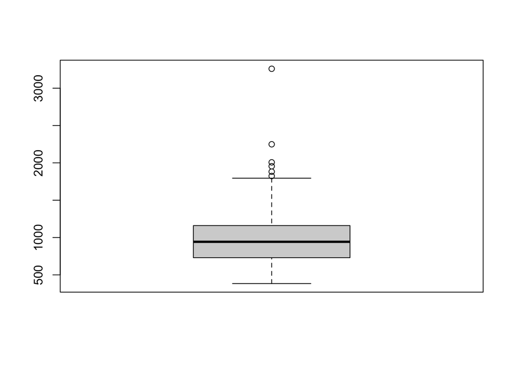

```r
# Interior변수의 boxplot 확인

boxplot(data7$Interior)
```

```r
# Interior변수에서 1.5 IQR을 넘는 극단값 확인
Lo = quantile(data7$Interior,0.25)-1.5*IQR(data7$Interior)
Up = quantile(data7$Interior,0.75)+1.5*IQR(data7$Interior)
outliers_int =data7$Interior[(data7$Interior<Lo) | (data7$Interior>Up)]
outliers_int
```

```
[1] 2007 1882 1955 2249 3260 1824
```

```r
# Interior변수 극단값의 인덱스 추출 및 제거(data8)
outliers_int_index = which((data7$Interior<Lo) | (data7$Interior>Up))
data8 = data7[-outliers_int_index,]
```

6개 제거

### Area 수준별 갯수 확인 10개 미만일경우 제거

```r
# Area factor의 수준별 빈도수 확인
table(data8$Area)
```

```
 AG  AH   C  CP   E  FP  HS   K   M   N  NW  PS  RA  RS  SH   W
 11  34   2  22  18   2  71  14 103  13   5  15  36  14   6  29
```

C,FP,NW,SH

```r
# Area변수에서 C,FP,NW,SH 만 뽑아내기

outliers_area =data8$Area[(data8$Area=="C") | (data8$Area=="FP") | (data8$Area=="NW") | (data8$Area=="SH")]
outliers_area
```

```
 [1] C  FP SH SH SH SH SH SH FP NW NW NW NW C  NW
Levels: AG AH C CP E FP HS K M N NW PS RA RS SH W
```

```r
# Area변수 C,FP,NW,SH 인덱스 추출 및 제거(data9)
outliers_area_index = which((data8$Area=="C") | (data8$Area=="FP") | (data8$Area=="NW") | (data8$Area=="SH"))

data9 = data8[-outliers_area_index,]
```

15개 제거

### RC 0,1 갯수 확인 (한쪽이 너무 적으면 제거)

```r
# RC factor의 수준별 빈도수 확인

table(data9$RC)
```

```
  0   1
126 254
```

둘다 100개 이상의 데이터를 갖고 있으므로 한쪽 제거 안함

### 너무 크거나 작은 Tax 제거

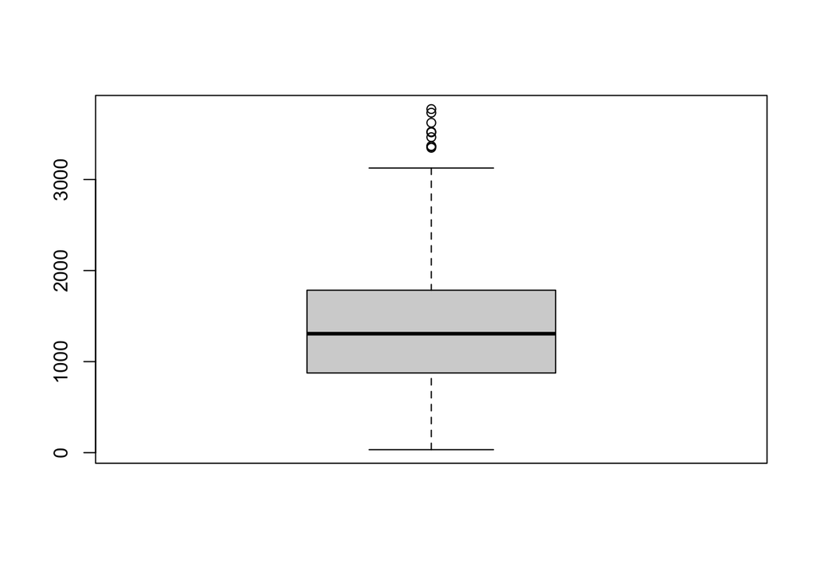

```r
# Tax 변수의 boxplot 확인

boxplot(data9$Tax)
```

```r
# Tax변수에서 1.5 IQR을 넘는 극단값 확인

Lo = quantile(data9$Tax,0.25)-1.5*IQR(data9$Tax)
Up = quantile(data9$Tax,0.75)+1.5*IQR(data9$Tax)
outliers_tax =data9$Tax[(data9$Tax<Lo) | (data9$Tax>Up)]
outliers_tax
```

```
[1] 3518 3734 3624 3363 3525 3465 3349 3774 3368
```

```r
# Tax변수 극단값의 인덱스 추출 및 제거(dataA)

outliers_tax_index = which((data9$Tax<Lo) | (data9$Tax>Up))
dataA = data9[-outliers_tax_index,]
```

9개 제거

### 너무 크거나 작은 Condo 제거

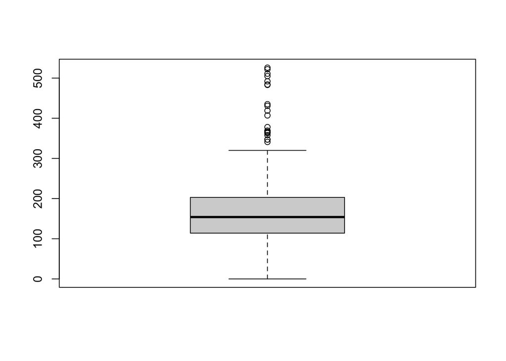

```r
# Condo 변수의 boxplot 확인

boxplot(data9$Condo)
```

```r
# Condo변수에서 1.5 IQR을 넘는 극단값 확인


Lo = quantile(dataA$Condo,0.25)-1.5*IQR(dataA$Condo)
Up = quantile(dataA$Condo,0.75)+1.5*IQR(dataA$Condo)
outliers_Condo =dataA$Condo[(dataA$Condo<Lo) | (dataA$Condo>Up)]
outliers_Condo
```

```
 [1] 366 347 341 378 363 358 364 347 435 419 522 369 407
```

```r
# Condo변수 극단값의 인덱스 추출 및 제거(dataB)


outliers_Condo_index = which((dataA$Condo<Lo) | (dataA$Condo>Up))
dataB = dataA[-outliers_Condo_index,]
```

### 너무 많거나 적은 Rooms 제거

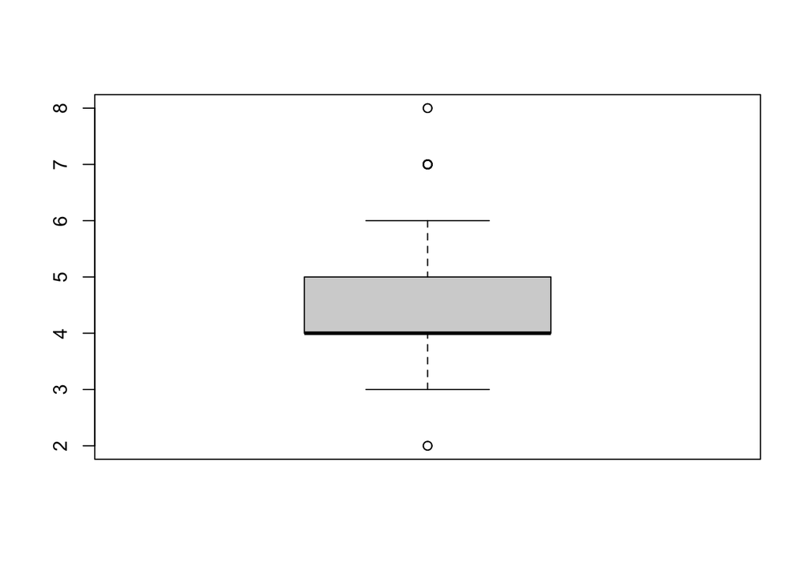

```r
# Rooms 변수의 boxplot 확인

boxplot(dataB$Rooms)
```

```r
# Rooms변수에서 1.5 IQR을 넘는 극단값 확인

Lo = quantile(dataB$Rooms,0.25)-1.5*IQR(dataB$Rooms)
Up = quantile(dataB$Rooms,0.75)+1.5*IQR(dataB$Rooms)
outliers_Rooms =dataB$Rooms[(dataB$Rooms<Lo) | (dataB$Rooms>Up)]
outliers_Rooms
```

```
 [1] 8 7 7 7 7 7 8 7 7 7 7 7 7 7 2 7 2 7
```

```r
# Rooms 변수 극단값의 인덱스 추출 및 제거(dataC)

outliers_Rooms_index = which((dataB$Rooms<Lo) | (dataB$Rooms>Up))
dataC = dataB[-outliers_Rooms_index,]
```

18개 제거

### 너무 많거나 적은 BED/Rooms = BedPerR 제거

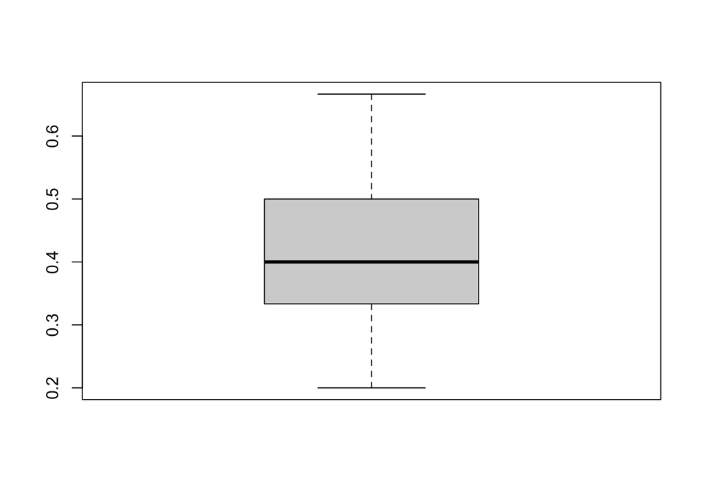

```r
# BedPerR 변수의 boxplot 확인

boxplot(dataC$BedPerR)
```

아웃라이어 보이지 않음 제거 x

### 너무 많거나 적은 BATH/Rooms 제거

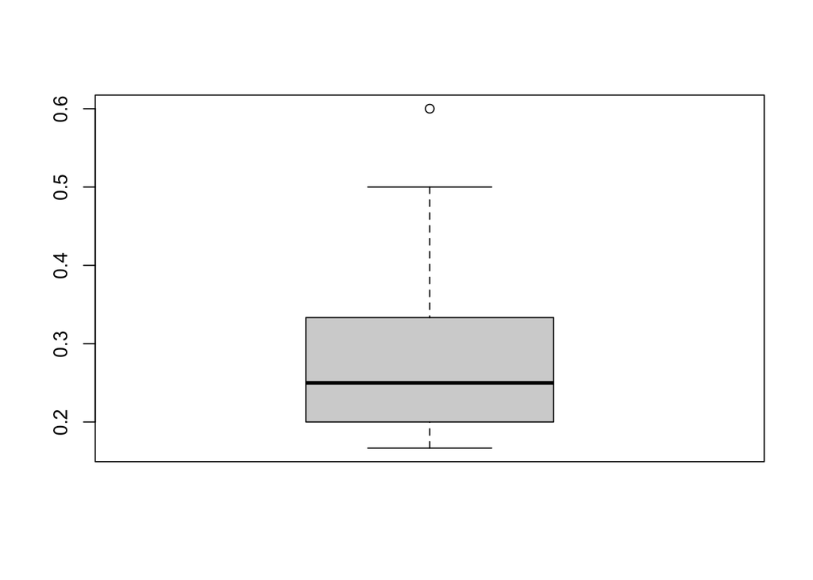

```r
# BathPerR 변수의 boxplot 확인

boxplot(dataC$BathPerR)
```

```r
# BathPerR변수에서 1.5 IQR을 넘는 극단값 확인

Lo = quantile(dataC$BathPerR,0.25)-1.5*IQR(dataC$BathPerR)
Up = quantile(dataC$BathPerR,0.75)+1.5*IQR(dataC$BathPerR)
outliers_BathPerR =dataC$BathPerR[(dataC$BathPerR<Lo) | (dataC$BathPerR>Up)]
outliers_BathPerR
```

```
[1] 0.6
```

```r
# BathPerR 변수 극단값의 인덱스 추출 및 제거(dataD)

outliers_BathPerR_index = which((dataC$BathPerR<Lo) | (dataC$BathPerR>Up))
dataD = dataC[-outliers_BathPerR_index,]
```

1개 제거

### outlier 제거 결과

**Note**

결과적으로 총 339개 관측치의 아래와 같은 데이터만 남았다.

```r
head(dataD)
```

```
  AddressNo AddressName Street Unit Area AreaCode Price1 Price2 SalePrice YearF
1        73     Allston     St    1   CP        4 109000 109000    106000  1993
2       239     Allston     St    2   CP        4 127000 127000    125000  1993
3        83       Amory     St    3    M        9 123000 100000     95000  1993
4       107      Antrim     St    1    M        9 219000 210000    206000  1991
6       135      Antrim     St    1    M        9 169000 152000    136500  1992
7        95      Antrim     St    3    M        9 245000 214900    202000  1992
  MonthF DateF  CloseDate Days Interior Bed Bath Rooms Condo  Tax RC   PrPerI
1     07    17 1993-10-22   97      834   2    1     4    70  490  0 127.0983
2     08    21 1993-10-22   62      850   2    1     5   100  923  1 147.0588
3     03    06 1993-09-30  208      730   2    1     4   185  575  0 130.1370
4     03    17 1991-08-23  159     1460   3    2     6   100 1582  1 141.0959
6     05    30 1992-09-23  116     1225   2    1     6   100 1698  1 111.4286
7     08    08 1993-01-15  160     1585   2    1     6   100 1402  1 127.4448
    BedPerR  BathPerR
1 0.5000000 0.2500000
2 0.4000000 0.2000000
3 0.5000000 0.2500000
4 0.5000000 0.3333333
6 0.3333333 0.1666667
7 0.3333333 0.1666667
```

## PrPerI ~ Area 분산분석(dataD)

```r
# Area 변수 수준별 빈도수 확인

table(dataD$Area)
```

```
AG AH  C CP  E FP HS  K  M  N NW PS RA RS SH  W
10 31  0 20 10  0 67  9 93 13  0 14 34 14  0 24
```

```r
M2 = aov(PrPerI ~ Area, dataD)
anova(M2)
```

```
Analysis of Variance Table

Response: PrPerI
           Df Sum Sq Mean Sq F value    Pr(>F)
Area       11 181548 16504.4  23.869 < 2.2e-16 ***
Residuals 327 226111   691.5
---
Signif. codes:  0 '***' 0.001 '**' 0.01 '*' 0.05 '.' 0.1 ' ' 1
```

Area의 모든 평균이 같다는 귀무가설을 기각했다.

등분산성을 확인.

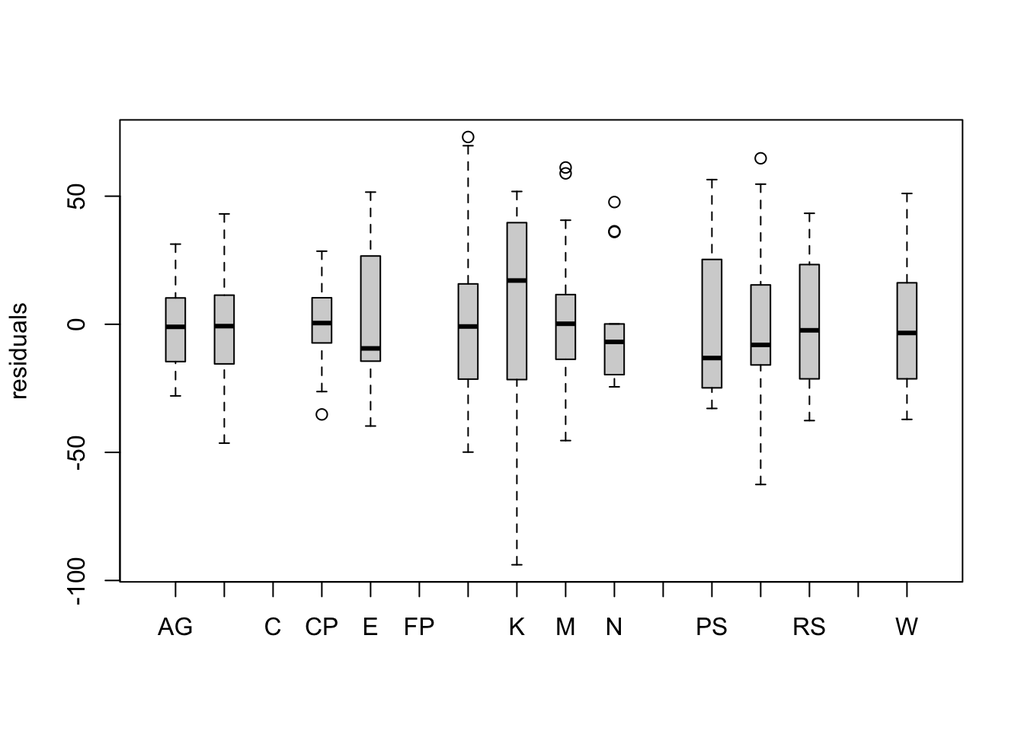

```r
ri = M2$residuals
boxplot(ri ~ dataD$Area, xlab = "", ylab = "residuals", range= 1.5, boxwex = 0.4) # boxwex는 상자폭을 0.4배 줄이는 옵션
```

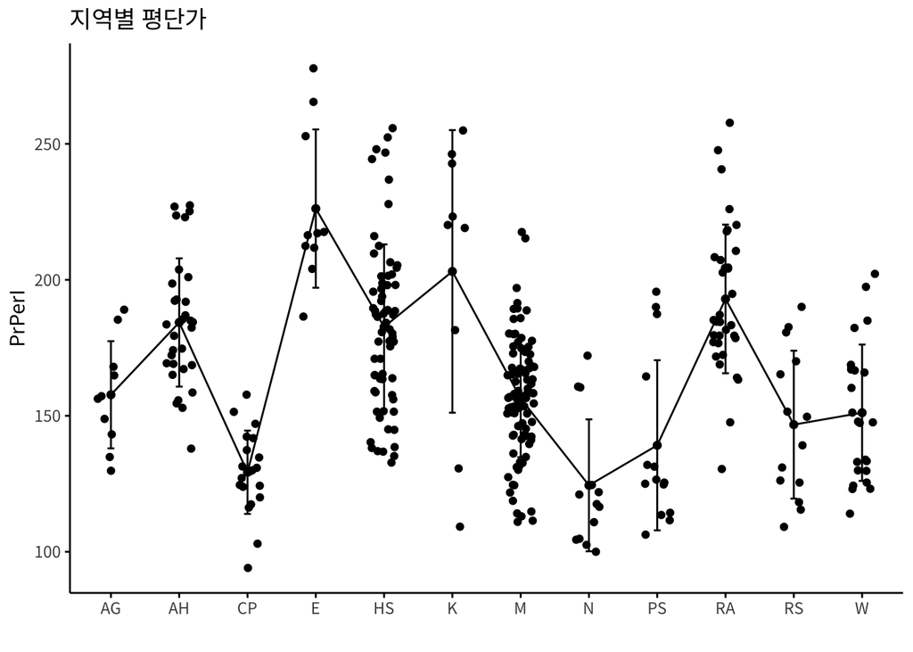

```r
ggpubr::ggline(dataD, x = "Area", y = "PrPerI", add = c("mean_sd", "jitter"),
       title = "지역별 평단가", ylab ="PrPerI", xlab = "", ggtheme = theme_classic(base_family = "Noto Sans KR") )
```

여전히 Area별로 분포가 크게 다른 것으로 보아 등분산성을 만족하지 않는 것으로 보인다.

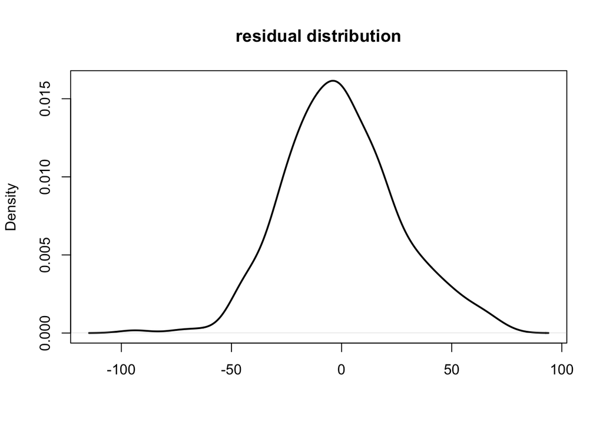

```r
plot(density(M2$residuals),xlab = "",main = "residual distribution", lwd = 2)
```

잔차의 분포가 상당히 정규성을 띄는 분포를 보인다.

그러므로 bartlett test를 이용하여 등분산성을 검정한다.

```r
bartlett.test(PrPerI ~ Area, dataD)
```

```
    Bartlett test of homogeneity of variances

data:  PrPerI by Area
Bartlett's K-squared = 32.215, df = 11, p-value = 0.0007043
```

p값이(`0.0007043`) 등분산성을 만족한다는 귀무가설을 기각하고 있기 때문에 등분산성을 갖고 있다고 볼 수 없다.

때문에 비모수검정을 진행한다.

### 비모수검정

```r
kruskal.test(PrPerI ~ Area, dataD)
```

```
    Kruskal-Wallis rank sum test

data:  PrPerI by Area
Kruskal-Wallis chi-squared = 147.4, df = 11, p-value < 2.2e-16
```

p-value가 매우 작으므로 그룹간 차이가 존재하는 것으로 판단할 수 있다.

사후검정, 다중비교를 진행한다. 작은 차이라도 찾아내기 위해 fisher lsd 검정과 같이 개별 유의수준을 통제하는 방식으로 wilcoxon 검정을 사용한다.

```r
# dataD Wilcoxon 검정 - 다중 비교 사후검정 (순위기반)

pairwise.wilcox.test(dataD$PrPerI, dataD$Area, p.adjust.method = "none")
```

```
    Pairwise comparisons using Wilcoxon rank sum exact test

data:  dataD$PrPerI and dataD$Area

   AG      AH      CP      E       HS      K       M       N       PS
AH 0.00300 -       -       -       -       -       -       -       -
CP 0.00032 1.7e-12 -       -       -       -       -       -       -
E  2.2e-05 0.00028 6.7e-08 -       -       -       -       -       -
HS 0.01067 0.77744 5.0e-10 0.00015 -       -       -       -       -
K  0.05348 0.13820 0.00204 0.90483 0.10104 -       -       -       -
M  0.92457 1.7e-07 8.8e-07 5.5e-07 4.3e-08 0.00577 -       -       -
N  0.00412 1.0e-07 0.16944 1.7e-06 9.4e-07 0.00107 0.00018 -       -
PS 0.05591 0.00012 0.87660 7.1e-06 6.2e-05 0.00857 0.01826 0.06094 -
RA 0.00059 0.19717 1.2e-12 0.00242 0.09618 0.17745 3.1e-10 2.0e-09 2.6e-05
RS 0.31192 0.00012 0.09687 2.0e-06 0.00035 0.01297 0.19751 0.01933 0.37609
W  0.36044 2.2e-05 0.00481 6.1e-08 3.4e-05 0.00962 0.29234 0.00129 0.09953
   RA      RS
AH -       -
CP -       -
E  -       -
HS -       -
K  -       -
M  -       -
N  -       -
PS -       -
RA -       -
RS 1.8e-05 -
W  2.2e-07 0.66475

P value adjustment method: none
```

wilcoxon 검정을 기반으로 두 변수간 p값이 0.1 이하인 경우 붉은 타일이 나타나도록 했다.

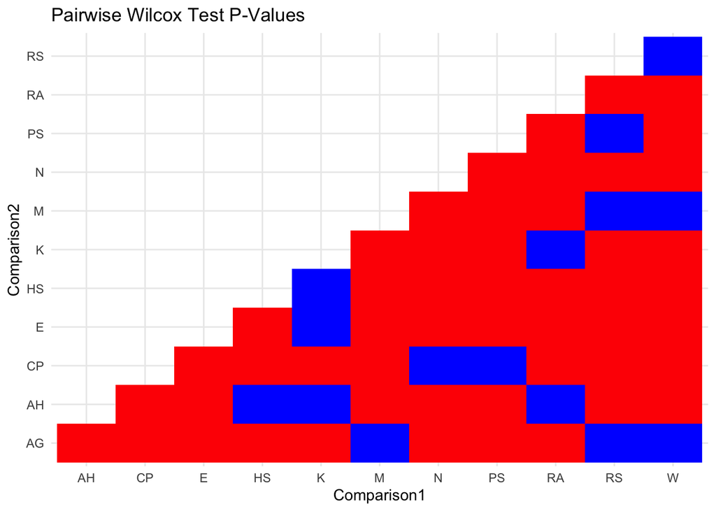

```r
# Area 변수의 순서를 변경한 dataE

dataE = dataD
# Area 변수의 순서를 변경
dataE$Area <- factor(dataD$Area, levels = c("E","K","RA","AH", "HS","AG" ,"M","W","RS","PS","CP","N"))
```

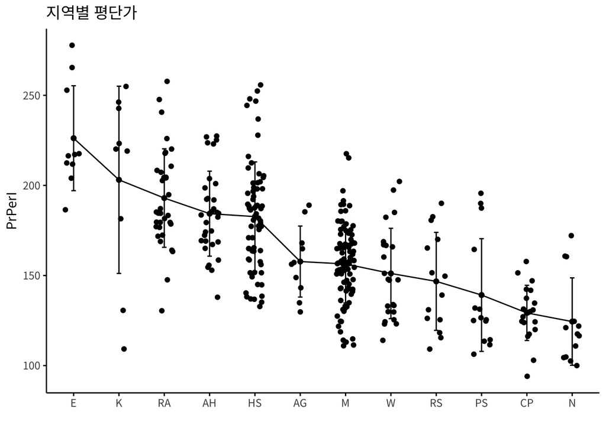

### Area 분산분석 결과

위 분산분석결과를 통해 평단가가 차이 나지 않는 지역을 묶은 새로운 Zone 변수 생성

1Zone = “E”  
2Zone = “K”  
3Zone = “RA”  
4Zone = “AH”,“HS”  
5Zone = “AG”,“M”,“W”,“RS”  
6Zone = “PS”,“CP”  
7Zone = “N”

```r
# Zone 변수 추가한 dataF

dataF = dataE
for(i in 1:nrow(dataF)){
  if(dataF$Area[i] == "E"){
    dataF$Zone[i] = "1Zone"
    }
  else if(dataF$Area[i] == "K"){
    dataF$Zone[i] = "2Zone"
    }
  else if(dataF$Area[i] == "RA"){
    dataF$Zone[i] = "3Zone"
    }
  else if(dataF$Area[i] == "AH"|dataF$Area[i] == "HS"){
    dataF$Zone[i] = "4Zone"
    }
  else if(dataF$Area[i] == "AG"|dataF$Area[i] == "M"|dataF$Area[i] == "W"|dataF$Area[i] == "RS"){
    dataF$Zone[i] = "5Zone"
    }
  else if(dataF$Area[i] == "PS"|dataF$Area[i] == "CP"){
    dataF$Zone[i] = "6Zone"
    }
  else if(dataF$Area[i] == "N"){
    dataF$Zone[i] = "7Zone"
    }
}
dataF$Zone = as.factor(dataF$Zone)
```

```r
head(dataF)
```

```
  AddressNo AddressName Street Unit Area AreaCode Price1 Price2 SalePrice YearF
1        73     Allston     St    1   CP        4 109000 109000    106000  1993
2       239     Allston     St    2   CP        4 127000 127000    125000  1993
3        83       Amory     St    3    M        9 123000 100000     95000  1993
4       107      Antrim     St    1    M        9 219000 210000    206000  1991
6       135      Antrim     St    1    M        9 169000 152000    136500  1992
7        95      Antrim     St    3    M        9 245000 214900    202000  1992
  MonthF DateF  CloseDate Days Interior Bed Bath Rooms Condo  Tax RC   PrPerI
1     07    17 1993-10-22   97      834   2    1     4    70  490  0 127.0983
2     08    21 1993-10-22   62      850   2    1     5   100  923  1 147.0588
3     03    06 1993-09-30  208      730   2    1     4   185  575  0 130.1370
4     03    17 1991-08-23  159     1460   3    2     6   100 1582  1 141.0959
6     05    30 1992-09-23  116     1225   2    1     6   100 1698  1 111.4286
7     08    08 1993-01-15  160     1585   2    1     6   100 1402  1 127.4448
    BedPerR  BathPerR  Zone
1 0.5000000 0.2500000 6Zone
2 0.4000000 0.2000000 6Zone
3 0.5000000 0.2500000 5Zone
4 0.5000000 0.3333333 5Zone
6 0.3333333 0.1666667 5Zone
7 0.3333333 0.1666667 5Zone
```

## PrPerI ~ YearF 분산분석(dataF)

```r
# dataF를 이용한 PrPerI ~ YearF분산분석 M3 정의


M3 = aov(PrPerI ~ YearF, dataF)
anova(M3)
```

```
Analysis of Variance Table

Response: PrPerI
           Df Sum Sq Mean Sq F value  Pr(>F)
YearF       5  15049  3009.8  2.5529 0.02763 *
Residuals 333 392610  1179.0
---
Signif. codes:  0 '***' 0.001 '**' 0.01 '*' 0.05 '.' 0.1 ' ' 1
```

YearF에 따른 PrPerI의 모든 평균이 같다는 귀무가설을 기각했다.

등분산성을 확인해보자.

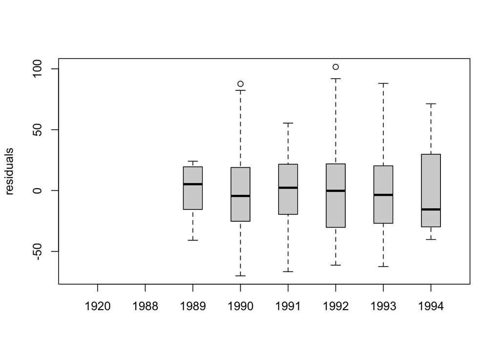

```r
ri = M3$residuals
boxplot(ri ~ dataF$YearF, xlab = "", ylab = "residuals", range= 1.5, boxwex = 0.4) # boxwex는 상자폭을 0.4배 줄이는 옵션
```

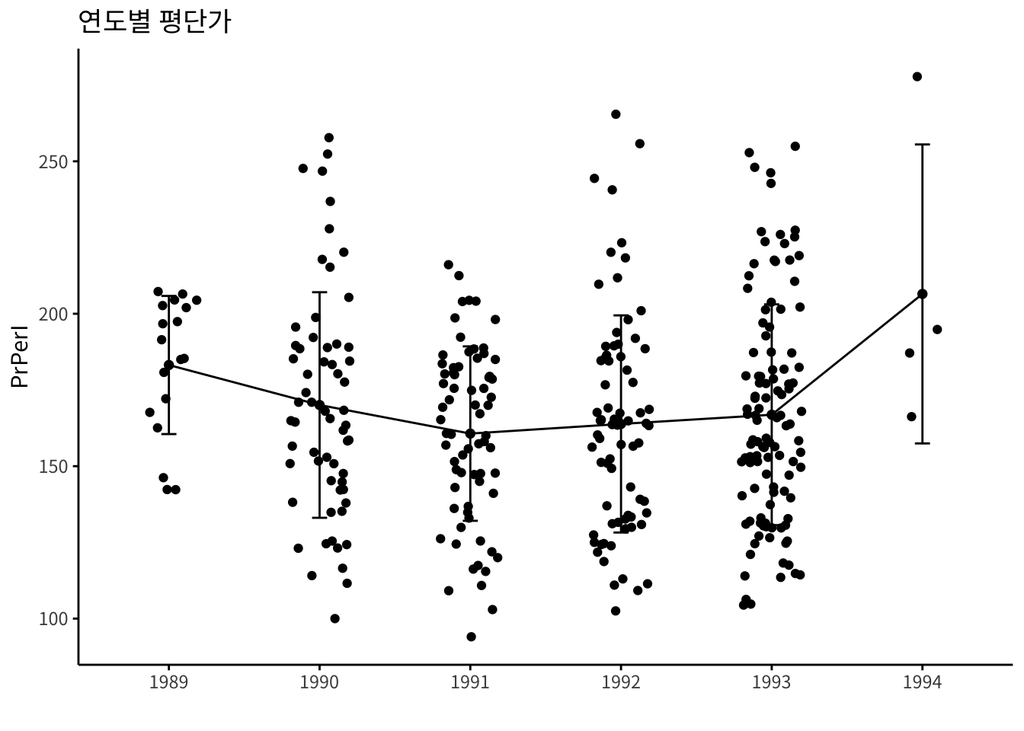

```r
ggpubr::ggline(dataF, x = "YearF", y = "PrPerI", add = c("mean_sd", "jitter"),
       title = "연도별 평단가", ylab ="PrPerI", xlab = "", ggtheme = theme_classic(base_family = "Noto Sans KR") )
```

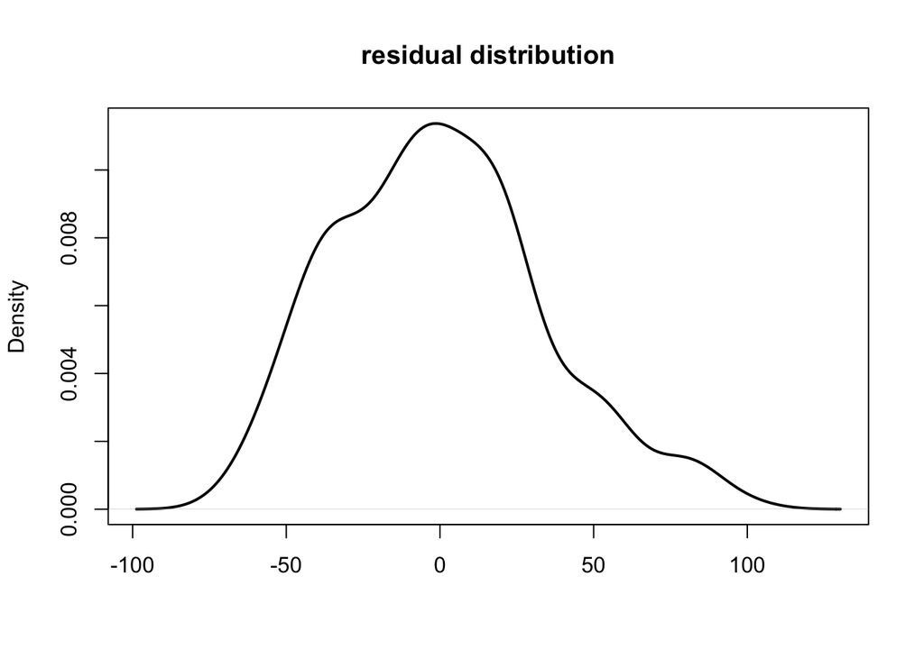

```r
plot(density(M3$residuals),xlab = "",main = "residual distribution", lwd = 2)
```

비교적 종모양을 띄고 있으나 비대칭이 Area 분산분석보다 심하므로, levene test를 하는 편이 좋아 보인다.

```r
car::leveneTest(M3) # 디폴트 center = median
```

```
Levene's Test for Homogeneity of Variance (center = median)
       Df F value Pr(>F)
group   5  1.2742 0.2746
      333
```

등분산성을 만족하고 있다는 결과가 나왔으므로, 검정력이 좋은 Fisher의 LSD를 진행한다.

### fisher LSD

```r
result = DescTools::PostHocTest(M3,method = "lsd")
result
```

```
  Posthoc multiple comparisons of means : Fisher LSD
    95% family-wise confidence level

$YearF
                diff     lwr.ci     upr.ci   pval
1990-1989 -13.120647 -31.238230  4.9969356 0.1552
1991-1989 -22.493556 -40.343791 -4.6433215 0.0137 *
1992-1989 -19.332317 -37.060428 -1.6042061 0.0327 *
1993-1989 -16.309274 -33.471950  0.8534008 0.0625 .
1994-1989  23.310869 -14.025576 60.6473144 0.2203
1991-1990  -9.372910 -21.203586  2.4577671 0.1201
1992-1990  -6.211670 -17.857268  5.4339273 0.2948
1993-1990  -3.188628 -13.953916  7.5766614 0.5605
1994-1990  36.431516   1.569730 71.2933027 0.0406 *
1992-1991   3.161239  -8.063913 14.3863911 0.5800
1993-1991   6.184282  -4.124721 16.4932846 0.2388
1994-1991  45.804426  11.080828 80.5280236 0.0099 **
1993-1992   3.023043  -7.073024 13.1191097 0.5563
1994-1992  42.643186   7.982210 77.3041628 0.0160 *
1994-1993  39.620144   5.244938 73.9953497 0.0240 *

---
Signif. codes:  0 '***' 0.001 '**' 0.01 '*' 0.05 '.' 0.1 ' ' 1
```

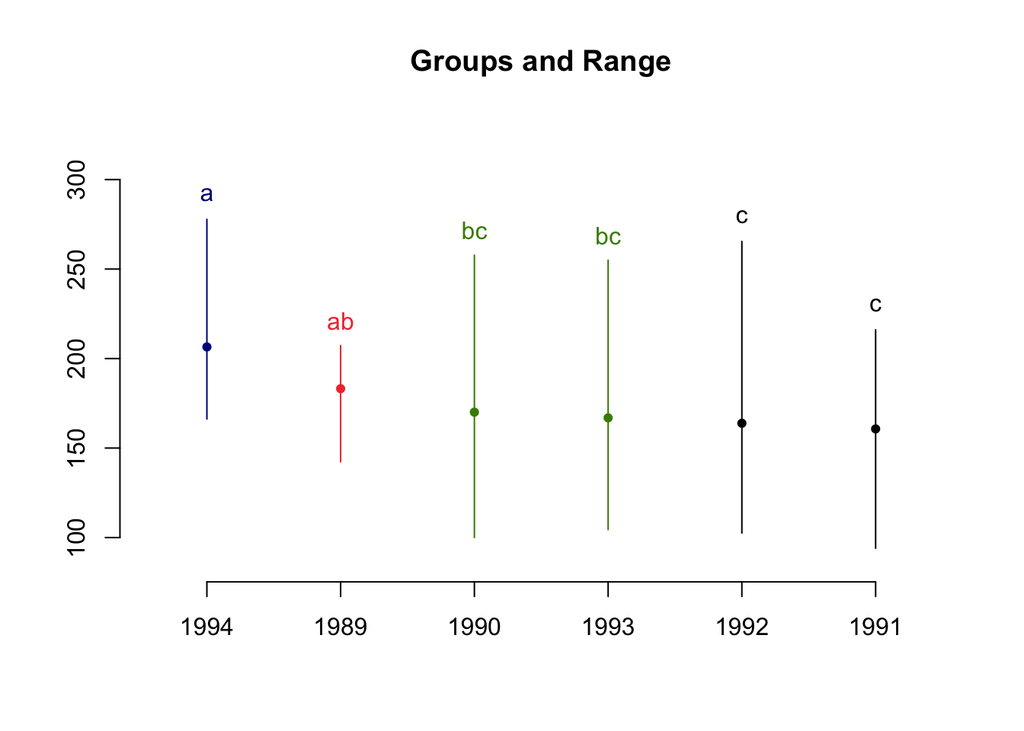

```r
plot(LSD.test(M3, "YearF", p.adj = "none"))
```

### 연도별 분산분석 결과

위 분산분석결과를 통해 평단가가 차이 나지 않는 연도를 묶은(색깔별로 묶었음) 새로운 YearM 변수 생성

“1994” = “1994”  
“1989” = “1989”  
“1990,93” = “1990”,“1993”  
“1991,92” = “1991”,“1992”

```r
# YearM 변수 추가한 dataG


dataG = dataF
for(i in 1:nrow(dataG)){
  if(dataG$YearF[i] == "1994"){
    dataG$YearM[i] = "1994"
    }
  else if(dataG$YearF[i] == "1989"){
    dataG$YearM[i] = "1989"
    }
  else if(dataG$YearF[i] == "1990"|dataG$YearF[i] == "1993"){
    dataG$YearM[i] = "1990,93"
    }
  else if(dataG$YearF[i] == "1991"|dataG$YearF[i] == "1992"){
    dataG$YearM[i] = "1991,92"
    }
}
dataG$YearM = as.factor(dataG$YearM)
```

```r
head(dataG)
```

```
  AddressNo AddressName Street Unit Area AreaCode Price1 Price2 SalePrice YearF
1        73     Allston     St    1   CP        4 109000 109000    106000  1993
2       239     Allston     St    2   CP        4 127000 127000    125000  1993
3        83       Amory     St    3    M        9 123000 100000     95000  1993
4       107      Antrim     St    1    M        9 219000 210000    206000  1991
6       135      Antrim     St    1    M        9 169000 152000    136500  1992
7        95      Antrim     St    3    M        9 245000 214900    202000  1992
  MonthF DateF  CloseDate Days Interior Bed Bath Rooms Condo  Tax RC   PrPerI
1     07    17 1993-10-22   97      834   2    1     4    70  490  0 127.0983
2     08    21 1993-10-22   62      850   2    1     5   100  923  1 147.0588
3     03    06 1993-09-30  208      730   2    1     4   185  575  0 130.1370
4     03    17 1991-08-23  159     1460   3    2     6   100 1582  1 141.0959
6     05    30 1992-09-23  116     1225   2    1     6   100 1698  1 111.4286
7     08    08 1993-01-15  160     1585   2    1     6   100 1402  1 127.4448
    BedPerR  BathPerR  Zone   YearM
1 0.5000000 0.2500000 6Zone 1990,93
2 0.4000000 0.2000000 6Zone 1990,93
3 0.5000000 0.2500000 5Zone 1990,93
4 0.5000000 0.3333333 5Zone 1991,92
6 0.3333333 0.1666667 5Zone 1991,92
7 0.3333333 0.1666667 5Zone 1991,92
```

## 다중회귀분석

```r
# dataG 구조 확인
str(dataG)
```

```
'data.frame':   339 obs. of  26 variables:
 $ AddressNo  : Factor w/ 146 levels "1","10","10]",..: 128 57 133 6 19 139 97 19 18 108 ...
 $ AddressName: Factor w/ 112 levels "Allston","Amory",..: 1 1 2 3 3 3 3 3 3 5 ...
 $ Street     : Factor w/ 16 levels "Auburn","Ave",..: 14 14 14 14 14 14 14 14 14 14 ...
 $ Unit       : chr  "1" "2" "3" "1" ...
 $ Area       : Factor w/ 12 levels "E","K","RA","AH",..: 11 11 7 7 7 7 7 7 7 6 ...
 $ AreaCode   : num  4 4 9 9 9 9 9 9 9 1 ...
 $ Price1     : num  109000 127000 123000 219000 169000 ...
 $ Price2     : num  109000 127000 100000 210000 152000 ...
 $ SalePrice  : num  106000 125000 95000 206000 136500 ...
 $ YearF      : Factor w/ 8 levels "1920","1988",..: 7 7 7 5 6 6 7 7 7 5 ...
 $ MonthF     : Factor w/ 12 levels "01","02","03",..: 7 8 3 3 5 8 5 6 9 7 ...
 $ DateF      : Factor w/ 31 levels "01","02","03",..: 17 21 6 17 30 8 18 19 24 6 ...
 $ CloseDate  : POSIXct, format: "1993-10-22" "1993-10-22" ...
 $ Days       : num  97 62 208 159 116 160 80 157 123 83 ...
 $ Interior   : num  834 850 730 1460 1225 ...
 $ Bed        : num  2 2 2 3 2 2 3 3 3 2 ...
 $ Bath       : num  1 1 1 2 1 1 1 1 1 1 ...
 $ Rooms      : num  4 5 4 6 6 6 5 6 6 5 ...
 $ Condo      : num  70 100 185 100 100 100 163 150 100 80 ...
 $ Tax        : num  490 923 575 1582 1698 ...
 $ RC         : Factor w/ 2 levels "0","1": 1 2 1 2 2 2 1 2 2 2 ...
 $ PrPerI     : num  127 147 130 141 111 ...
 $ BedPerR    : num  0.5 0.4 0.5 0.5 0.333 ...
 $ BathPerR   : num  0.25 0.2 0.25 0.333 0.167 ...
 $ Zone       : Factor w/ 7 levels "1Zone","2Zone",..: 6 6 5 5 5 5 5 5 5 5 ...
 $ YearM      : Factor w/ 4 levels "1989","1990,93",..: 2 2 2 3 3 3 2 2 2 3 ...
```

### 다중 회귀 모형 Fullmodel

```
# LM1 = 모든 변수 상호작용 고려한 다중 회귀 모형
LM1 = lm(PrPerI ~ Interior * Zone * YearM * Days * Rooms * Bed * Bath * Condo * Tax * RC, dataG)
```

```
# LM1의 MSE 확인

F1 = anova(LM1)
F1[218,3] # LM1의 MSE

아래는 Fullmodel의 MSE
[1] 267.9195
```

```
# LM1을 활용한 Reyeme Affiar의 건물 가격 예측

predict(LM1, newdata = data.frame(Interior = 1040, Zone = "5Zone",YearM = "1994", Days = 24, Rooms = 5, Bed = 2, Bath = 1, Condo = 175 , Tax = 1121 , RC = "1"), interval = "prediction") #Days 24일은 4월 11일 ~ 5월 4일(당일 구매시) 기간 계산
#5Zone 은 건물이 위치한 Mid Cambridge(Area:M)의 Zone
```

### 다중 회귀 모형 - 단계별 선택법

```r
# 상호작용을 고려하지 않은 LM2 다중회귀 모형

LM2 = lm(PrPerI ~ Interior + Zone + YearM + Days + Rooms + Bed + Bath + Condo + Tax + RC, dataG)
```

```r
# LM2 다중회귀 모형의 MSE확인

F2 = anova(LM2)
F2[11,3] # LM2의 MSE
```

```
[1] 579.6425
```

```r
# LM2 다중회귀 모형의 model selection 단계별 선택법

step = stepAIC(LM2, scope = list(upper = ~ Interior*Zone*YearM*Days * Rooms * Bed * Bath * Condo * Tax * RC, lower = ~1),direction="both",trace = FALSE )
```

```r
# LM2 다중회귀 모형의 model selection 단계별 선택법 결과

step$anova
```

```
Stepwise Model Path
Analysis of Deviance Table

Initial Model:
PrPerI ~ Interior + Zone + YearM + Days + Rooms + Bed + Bath +
    Condo + Tax + RC

Final Model:
PrPerI ~ Interior + Zone + YearM + Days + Rooms + Bed + Bath +
    Condo + Tax + RC + Rooms:Bath + Rooms:RC + Condo:RC + Interior:Tax +
    Rooms:Tax + Interior:Bed + Days:Tax

            Step Df   Deviance Resid. Df Resid. Dev      AIC
1                                    321   186065.2 2174.362
2   + Rooms:Bath  1 14013.5783       320   172051.7 2149.817
3     + Rooms:RC  1  6311.8669       319   165739.8 2139.147
4     + Condo:RC  1  4287.4994       318   161452.3 2132.262
5 + Interior:Tax  1  2293.2031       317   159159.1 2129.413
6    + Rooms:Tax  1  2561.0429       316   156598.1 2125.913
7 + Interior:Bed  1  1222.3379       315   155375.7 2125.257
8     + Days:Tax  1   956.0451       314   154419.7 2125.165
```

```r
# 단계별 선택법에 의해 도출된 LM9

LM9 =lm(PrPerI ~ Interior + Zone + YearM + Days + Rooms + Bed + Bath +
    Condo + Tax + RC + Rooms:Bath + Rooms:RC + Condo:RC + Interior:Tax +
    Rooms:Tax + Interior:Bed + Days:Tax,dataG)
F9 = anova(LM9)
F9[18,3] # MSE = 491.7824
```

```
[1] 491.7824
```

### Reyeme Affiar의 건물 가격 예측

```r
# LM9을 활용한 Reyeme Affiar의 건물 가격 예측

pre = predict(LM9, newdata = data.frame(Interior = 1040, Zone = "5Zone",YearM = "1994", Days = 24, Rooms = 5, Bed = 2, Bath = 1, Condo = 175 , Tax = 1121 , RC = "1"), interval = "prediction")
#Days 24일은 4월 11일 ~ 5월 4일(당일 구매시) 기간 계산
#5Zone 은 건물이 위치한 Mid Cambridge(Area:M)의 Zone
pre
```

```
       fit      lwr      upr
1 167.6632 117.9428 217.3836
```

```r
pre *1040
```

```
       fit      lwr    upr
1 174369.8 122660.6 226079
```

위 예측값은 SalePrice/Interior 이므로 Interior를 곱하면 아래와 같다.

```r
226079-122660.6
```

```
[1] 103418.4
```

```
  fit      lwr      upr
174369.7 122660.5 226078.9
```

## 다중공선성

### LM9모형에 사용한 변수간 상관관계 확인(수치형 변수만)

```r
dataG_N = dataG[,c("PrPerI","Interior","Days","Rooms","Bed","Bath","Condo","Tax")]
```

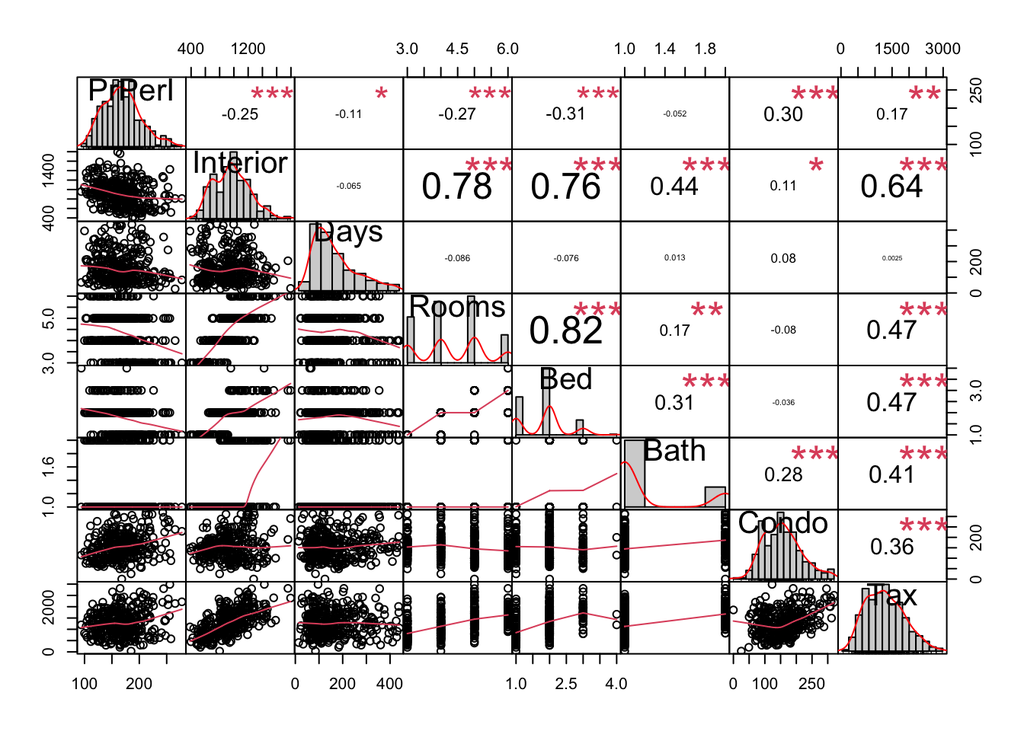

```r
chart.Correlation(dataG_N)
```

Interior - Rooms  
Rooms - Bed  
Interior - Bed  
Tax - Interior

위 변수간에 상관관계가 특히 높다.

LM9 다중회귀모형의 회귀계수를 살펴보자.

```r
LM9$coefficients
```

```
  (Intercept)      Interior     Zone2Zone     Zone3Zone     Zone4Zone
 4.317135e+02 -8.332000e-02 -1.394745e+01 -9.997601e+00 -1.779426e+01
    Zone5Zone     Zone6Zone     Zone7Zone  YearM1990,93  YearM1991,92
-3.874210e+01 -5.728407e+01 -6.362132e+01 -2.213001e+01 -2.697355e+01
    YearM1994          Days         Rooms           Bed          Bath
-1.231955e+01 -1.037574e-01 -2.956552e+01  9.264585e+00 -1.336912e+02
        Condo           Tax           RC1    Rooms:Bath     Rooms:RC1
 9.167909e-02  1.469227e-03 -5.216133e+01  2.774987e+01  1.375342e+01
    Condo:RC1  Interior:Tax     Rooms:Tax  Interior:Bed      Days:Tax
-9.195409e-02  4.934194e-05 -8.451105e-03 -1.386673e-02  3.257795e-05
```

5Zone, 1994년, RC=1 일 경우 Zone의 Reference Group = 1Zone YearM의 Reference Group = 1989

$$평단가 = 431.71 -0.083Interior -38.74(5Zone=1) -12.31(1994년=1) -0.103Days -29.56Rooms + 9.26Bed-133.6Bath+0.09167Condo +0.001469Tax-52.16RC(=1)+27.74 Rooms:Bath + 13.75Rooms:RC1 -0.09195 Condo:RC1 + 0.00004934 Interior:Tax -0.008451Rooms:Tax -0.01386Interior:Bed + 0.00003257 Days:Tax$$
Interior(-0.083) Rooms(-29.56)와 Bath(-133)의 회귀계수 부호 이상함

```r
F9 # LM9 회귀모형의 분산분석
```

```
Analysis of Variance Table

Response: PrPerI
              Df Sum Sq Mean Sq F value    Pr(>F)
Interior       1  25388 25388.2 51.6248 4.916e-12 ***
Zone           6 158171 26361.9 53.6048 < 2.2e-16 ***
YearM          3  11250  3749.9  7.6250 6.173e-05 ***
Days           1  10037 10036.6 20.4086 8.866e-06 ***
Rooms          1    368   367.9  0.7480 0.3877567
Bed            1    996   995.8  2.0248 0.1557428
Bath           1    602   601.7  1.2235 0.2695135
Condo          1   1467  1466.7  2.9824 0.0851582 .
Tax            1  13306 13306.3 27.0573 3.571e-07 ***
RC             1     10     9.6  0.0196 0.8888220
Rooms:Bath     1  14014 14013.6 28.4955 1.804e-07 ***
Rooms:RC       1   6312  6311.9 12.8347 0.0003942 ***
Condo:RC       1   4287  4287.5  8.7183 0.0033880 **
Interior:Tax   1   2293  2293.2  4.6630 0.0315754 *
Rooms:Tax      1   2561  2561.0  5.2077 0.0231561 *
Interior:Bed   1   1222  1222.3  2.4855 0.1159049
Days:Tax       1    956   956.0  1.9440 0.1642162
Residuals    314 154420   491.8
---
Signif. codes:  0 '***' 0.001 '**' 0.01 '*' 0.05 '.' 0.1 ' ' 1
```

Bath의 p값이 `0.2695135`으로 매우 높음.

다중공선성으로 인해 왜곡되고 있는 것일 수도 있으나, Rooms:Bath 상호작용항으로 인해 Bath의 p값이 올라갔을 수도 있다.

```r
vif(LM9)
```

```
there are higher-order terms (interactions) in this model
consider setting type = 'predictor'; see ?vif
```

```
                   GVIF Df GVIF^(1/(2*Df))
Interior      30.972332  1        5.565279
Zone           4.565540  6        1.134900
YearM          1.387884  3        1.056150
Days           6.496190  1        2.548762
Rooms         55.527329  1        7.451666
Bed           31.951406  1        5.652557
Bath          64.625473  1        8.038997
Condo          5.288306  1        2.299632
Tax           46.258185  1        6.801337
RC            45.289559  1        6.729752
Rooms:Bath    92.117098  1        9.597765
Rooms:RC      42.578161  1        6.525194
Condo:RC      13.179205  1        3.630317
Interior:Tax  93.876058  1        9.688966
Rooms:Tax    129.901513  1       11.397435
Interior:Bed  72.528245  1        8.516352
Days:Tax       9.691235  1        3.113075
```

GVIF(Generalized Variance Inflation Factor)^(1/(2*Df)) 또한 `8.038997`으로 높은 상태이다.

Bath를 제거한 다중회귀분석 결과를 보고 Bath를 제거할지 결정한다.

```r
LMA =lm(PrPerI ~ Interior + Zone + YearM + Days + Rooms + Bed +
    Condo + Tax + RC + Rooms:RC + Condo:RC + Interior:Tax +
    Rooms:Tax + Interior:Bed + Days:Tax,dataG)
FA = anova(LMA)
FA[16,3] # MSE = 541.5598
```

```
[1] 541.5598
```

MSE는 높아진 상태이다.

LMA 다중회귀모형의 회귀계수를 살펴보자.

```r
LMA$coefficients
```

```
  (Intercept)      Interior     Zone2Zone     Zone3Zone     Zone4Zone
 3.221943e+02 -1.245520e-01 -2.181028e+01 -2.207877e+01 -3.065006e+01
    Zone5Zone     Zone6Zone     Zone7Zone  YearM1990,93  YearM1991,92
-5.109871e+01 -6.978233e+01 -7.235645e+01 -2.335902e+01 -2.733208e+01
    YearM1994          Days         Rooms           Bed         Condo
-1.839061e+01 -1.109455e-01  5.721962e+00 -1.256260e+01  4.389747e-02
          Tax           RC1     Rooms:RC1     Condo:RC1  Interior:Tax
-2.253740e-03 -3.507087e+01  9.163022e+00 -4.397754e-02  5.028701e-05
    Rooms:Tax  Interior:Bed      Days:Tax
-7.831596e-03  6.980439e-03  3.544896e-05
```

5Zone, 1994년, RC=1 일 경우 Zone의 Reference Group = 1Zone YearM의 Reference Group = 1989

```r
FA # LMA 회귀모형의 분산분석
```

```
Analysis of Variance Table

Response: PrPerI
              Df Sum Sq Mean Sq F value    Pr(>F)
Interior       1  25388 25388.2 46.8797 3.939e-11 ***
Zone           6 158171 26361.9 48.6777 < 2.2e-16 ***
YearM          3  11250  3749.9  6.9242 0.0001580 ***
Days           1  10037 10036.6 18.5328 2.231e-05 ***
Rooms          1    368   367.9  0.6793 0.4104540
Bed            1    996   995.8  1.8387 0.1760735
Condo          1   1801  1800.8  3.3251 0.0691732 .
Tax            1  13574 13573.6 25.0638 9.234e-07 ***
RC             1      6     6.3  0.0116 0.9141438
Rooms:RC       1   2257  2256.7  4.1671 0.0420462 *
Condo:RC       1   1999  1999.3  3.6918 0.0555804 .
Interior:Tax   1   7760  7759.7 14.3284 0.0001837 ***
Rooms:Tax      1   1603  1602.6  2.9593 0.0863646 .
Interior:Bed   1    181   181.1  0.3344 0.5634729
Days:Tax       1   1137  1136.6  2.0987 0.1484196
Residuals    316 171133   541.6
---
Signif. codes:  0 '***' 0.001 '**' 0.01 '*' 0.05 '.' 0.1 ' ' 1
```

Interior의 p값 `3.939e-11 ***`

Rooms의 p값 `0.4104540`

Bed의 p값 `0.1760735`

Tax의 p값 `9.234e-07 ***`

```r
vif(LMA)
```

```
there are higher-order terms (interactions) in this model
consider setting type = 'predictor'; see ?vif
```

```
                   GVIF Df GVIF^(1/(2*Df))
Interior      28.589104  1        5.346878
Zone           4.181818  6        1.126628
YearM          1.356194  3        1.052092
Days           6.465876  1        2.542809
Rooms         30.795167  1        5.549339
Bed           27.768873  1        5.269618
Condo          4.900118  1        2.213621
Tax           46.156217  1        6.793837
RC            43.473244  1        6.593424
Rooms:RC      39.642516  1        6.296230
Condo:RC      12.458829  1        3.529707
Interior:Tax  93.695525  1        9.679645
Rooms:Tax    129.701150  1       11.388641
Interior:Bed  62.580866  1        7.910807
Days:Tax       9.652238  1        3.106805
```

Vif값은 Interior, Rooms와 Bed가 비슷하고 Tax가 더 크다.

종합했을 때, 회귀계수 부호가 이상하고, p값과 vif 모두 큰 Bed변수를 추가로 제거하는 편이 나을거라 판단한다.

```r
LMB =lm(PrPerI ~ Interior + Zone + YearM + Days + Rooms  +
    Condo + Tax + RC + Rooms:RC + Condo:RC + Interior:Tax +
    Rooms:Tax + Days:Tax, dataG)
FB = anova(LMB)
FB[14,3] # MSE = 542.9674(소폭 상승)
```

```
[1] 542.9674
```

```r
LMB$coefficients
```

```
  (Intercept)      Interior     Zone2Zone     Zone3Zone     Zone4Zone
 3.227817e+02 -1.215396e-01 -2.398876e+01 -2.455574e+01 -3.289470e+01
    Zone5Zone     Zone6Zone     Zone7Zone  YearM1990,93  YearM1991,92
-5.383420e+01 -7.291909e+01 -7.482239e+01 -2.353924e+01 -2.720200e+01
    YearM1994          Days         Rooms         Condo           Tax
-1.915637e+01 -1.077187e-01  3.109161e+00  3.649090e-02 -6.112867e-03
          RC1     Rooms:RC1     Condo:RC1  Interior:Tax     Rooms:Tax
-3.617391e+01  9.323944e+00 -3.388115e-02  5.545544e-05 -7.962630e-03
     Days:Tax
 3.240863e-05
```

5Zone, 1994년, RC=1 일 경우 Zone의 Reference Group = 1Zone YearM의 Reference Group = 1989

$$평단가 = 322 -0.12Interior -53(5Zone=1) -19(1994년=1) -0.11Days +3.1Rooms +0.036Condo -0.0061Tax -36RC(=1) + 9.3Rooms:RC1 -0.033 Condo:RC1 + 0.00005 Interior:Tax -0.0079Rooms:Tax + 0.000032 Days:Tax$$

Interior(-0.12) 와 Tax(-0.0061)의 회귀계수 부호 이상하다.

```r
FB # LMB 회귀모형의 분산분석
```

```
Analysis of Variance Table

Response: PrPerI
              Df Sum Sq Mean Sq F value    Pr(>F)
Interior       1  25388 25388.2 46.7582 4.119e-11 ***
Zone           6 158171 26361.9 48.5516 < 2.2e-16 ***
YearM          3  11250  3749.9  6.9062 0.0001616 ***
Days           1  10037 10036.6 18.4847 2.281e-05 ***
Rooms          1    368   367.9  0.6775 0.4110567
Condo          1   1773  1773.1  3.2657 0.0716897 .
Tax            1  13216 13215.9 24.3402 1.304e-06 ***
RC             1      9     9.0  0.0166 0.8974421
Rooms:RC       1   2287  2286.7  4.2115 0.0409700 *
Condo:RC       1   1815  1815.0  3.3428 0.0684366 .
Interior:Tax   1   7813  7812.9 14.3893 0.0001779 ***
Rooms:Tax      1   1907  1907.1  3.5124 0.0618266 .
Days:Tax       1    962   961.8  1.7714 0.1841635
Residuals    318 172664   543.0
---
Signif. codes:  0 '***' 0.001 '**' 0.01 '*' 0.05 '.' 0.1 ' ' 1
```

Interior와 Tax의 p값은 모두 낮다.

```
              Df Sum Sq Mean Sq F value    Pr(>F)
Rooms          1    368   367.9  0.6775 0.4110567
```

Rooms 의 p값이 굉장히 높다. 그러나, 이는 상호작용항에 의한 것일 수 있다. (Rooms:RC, Rooms:Tax)

```r
vif(LMB)
```

```
there are higher-order terms (interactions) in this model
consider setting type = 'predictor'; see ?vif
```

```
                   GVIF Df GVIF^(1/(2*Df))
Interior      20.835183  1        4.564557
Zone           3.973236  6        1.121834
YearM          1.336993  3        1.049594
Days           6.421863  1        2.534140
Rooms         28.536914  1        5.341995
Condo          4.831127  1        2.197982
Tax           35.414948  1        5.951046
RC            43.179359  1        6.571100
Rooms:RC      39.463134  1        6.281969
Condo:RC      12.262650  1        3.501807
Interior:Tax  84.091053  1        9.170117
Rooms:Tax    124.900391  1       11.175884
Days:Tax       9.533300  1        3.087604
```

Rooms의 VIF(5.341995)가 약간 높다.

Rooms 변수를 제외한 모델과 제외하지 않은 모델의 비교를 통해 정하는 편이 나을 것이다.

```r
LMC =lm(PrPerI ~ Interior + Zone + YearM + Days  +
    Condo + Tax + RC + Condo:RC + Interior:Tax + Days:Tax, dataG)
FC = anova(LMC)
FC[11,3] # MSE = 556.9496(소폭 상승)
```

```
[1] 556.9496
```

```r
LMC$coefficients
```

```
  (Intercept)      Interior     Zone2Zone     Zone3Zone     Zone4Zone
 3.040052e+02 -8.805901e-02 -1.959893e+01 -2.883798e+01 -3.699868e+01
    Zone5Zone     Zone6Zone     Zone7Zone  YearM1990,93  YearM1991,92
-5.681836e+01 -7.541773e+01 -7.673313e+01 -2.246997e+01 -2.624700e+01
    YearM1994          Days         Condo           Tax           RC1
-1.350294e+01 -1.069911e-01  5.366386e-02 -1.691192e-02  8.182605e+00
    Condo:RC1  Interior:Tax      Days:Tax
-5.574854e-02  3.030146e-05  3.267070e-05
```

5Zone, 1994년, RC=1 일 경우 Zone의 Reference Group = 1Zone YearM의 Reference Group = 1989

```r
FC # LMB 회귀모형의 분산분석
```

```
Analysis of Variance Table

Response: PrPerI
              Df Sum Sq Mean Sq F value    Pr(>F)
Interior       1  25388 25388.2 45.5843 6.858e-11 ***
Zone           6 158171 26361.9 47.3327 < 2.2e-16 ***
YearM          3  11250  3749.9  6.7328 0.0002036 ***
Days           1  10037 10036.6 18.0207 2.864e-05 ***
Condo          1   2002  2001.8  3.5942 0.0588799 .
Tax            1  13058 13057.8 23.4452 2.002e-06 ***
RC             1      0     0.4  0.0008 0.9777717
Condo:RC       1   1860  1860.1  3.3398 0.0685507 .
Interior:Tax   1   6127  6127.0 11.0010 0.0010151 **
Days:Tax       1    985   985.3  1.7691 0.1844394
Residuals    321 178781   556.9
---
Signif. codes:  0 '***' 0.001 '**' 0.01 '*' 0.05 '.' 0.1 ' ' 1
```

Interior와 Tax의 p값은 모두 낮다.

[output not shown]

```r
vif(LMC)
```

```
there are higher-order terms (interactions) in this model
consider setting type = 'predictor'; see ?vif
```

```
                  GVIF Df GVIF^(1/(2*Df))
Interior      8.713773  1        2.951910
Zone          3.430126  6        1.108177
YearM         1.265462  3        1.040020
Days          6.323522  1        2.514661
Condo         4.411145  1        2.100273
Tax          19.028376  1        4.362153
RC           10.346593  1        3.216612
Condo:RC     11.511983  1        3.392931
Interior:Tax 31.785329  1        5.637848
Days:Tax      9.457185  1        3.075254
```

```r
LMD =lm(PrPerI ~ Interior + Zone + YearM + Days + Tax + RC + Interior:Tax + Days:Tax, dataG)
FD = anova(LMD)
FD[9,3] # MSE = 555.9376(소폭 하락)
```

```
[1] 555.9376
```

```r
LMD$coefficients
```

```
  (Intercept)      Interior     Zone2Zone     Zone3Zone     Zone4Zone
 3.191129e+02 -9.019557e-02 -1.942112e+01 -3.336293e+01 -4.143884e+01
    Zone5Zone     Zone6Zone     Zone7Zone  YearM1990,93  YearM1991,92
-6.122573e+01 -8.007057e+01 -8.059698e+01 -2.259949e+01 -2.621473e+01
    YearM1994          Days           Tax           RC1  Interior:Tax
-1.421188e+01 -1.137231e-01 -1.852511e-02 -7.024446e-01  3.184656e-05
     Days:Tax
 3.840543e-05
```

5Zone, 1994년, RC=1 일 경우 Zone의 Reference Group = 1Zone YearM의 Reference Group = 1989

```r
FD # LMB 회귀모형의 분산분석
```

```
Analysis of Variance Table

Response: PrPerI
              Df Sum Sq Mean Sq F value    Pr(>F)
Interior       1  25388 25388.2 45.6673 6.550e-11 ***
Zone           6 158171 26361.9 47.4188 < 2.2e-16 ***
YearM          3  11250  3749.9  6.7451 0.0001999 ***
Days           1  10037 10036.6 18.0535 2.813e-05 ***
Tax            1  14765 14765.2 26.5591 4.460e-07 ***
RC             1      9     8.9  0.0161 0.8991356
Interior:Tax   1   7055  7054.9 12.6901 0.0004230 ***
Days:Tax       1   1416  1416.3  2.5476 0.1114416
Residuals    323 179568   555.9
---
Signif. codes:  0 '***' 0.001 '**' 0.01 '*' 0.05 '.' 0.1 ' ' 1
```

Interior와 Tax의 p값은 모두 낮다.

[output not shown]

```r
vif(LMD)
```

```
there are higher-order terms (interactions) in this model
consider setting type = 'predictor'; see ?vif
```

```
                  GVIF Df GVIF^(1/(2*Df))
Interior      8.541463  1        2.922578
Zone          2.274639  6        1.070885
YearM         1.238079  3        1.036235
Days          6.139167  1        2.477734
Tax          18.442787  1        4.294507
RC            1.509725  1        1.228709
Interior:Tax 30.899267  1        5.558711
Days:Tax      9.091643  1        3.015235
```

```r
LME =lm(PrPerI ~ Interior + Zone + YearM + Days + Tax + Interior:Tax , dataG)
FE = anova(LME)
FE[7,3] # MSE = 556.9658(소폭 상승)
```

```
[1] 556.9658
```

```r
LME$coefficients
```

```
  (Intercept)      Interior     Zone2Zone     Zone3Zone     Zone4Zone
 3.111365e+02 -8.872317e-02 -2.110222e+01 -3.461285e+01 -4.205998e+01
    Zone5Zone     Zone6Zone     Zone7Zone  YearM1990,93  YearM1991,92
-6.258686e+01 -8.084820e+01 -8.207155e+01 -2.312855e+01 -2.696179e+01
    YearM1994          Days           Tax  Interior:Tax
-1.750015e+01 -6.575244e-02 -1.148803e-02  3.105558e-05
```

5Zone, 1994년, RC=1 일 경우 Zone의 Reference Group = 1Zone YearM의 Reference Group = 1989

$$평단가 = 311 -0.08Interior -62(5Zone=1) -17(1994년=1) -0.06Days -0.011Tax + 0.00003 Interior:Tax$$

```r
FE # LMB 회귀모형의 분산분석
```

```
Analysis of Variance Table

Response: PrPerI
              Df Sum Sq Mean Sq F value    Pr(>F)
Interior       1  25388 25388.2 45.5830 6.743e-11 ***
Zone           6 158171 26361.9 47.3313 < 2.2e-16 ***
YearM          3  11250  3749.9  6.7326  0.000203 ***
Days           1  10037 10036.6 18.0201 2.856e-05 ***
Tax            1  14765 14765.2 26.5101 4.551e-07 ***
Interior:Tax   1   7034  7034.1 12.6293  0.000436 ***
Residuals    325 181014   557.0
---
Signif. codes:  0 '***' 0.001 '**' 0.01 '*' 0.05 '.' 0.1 ' ' 1
```

Interior와 Tax의 p값은 모두 낮다.

[output not shown]

```r
vif(LME)
```

```
there are higher-order terms (interactions) in this model
consider setting type = 'predictor'; see ?vif
```

```
                  GVIF Df GVIF^(1/(2*Df))
Interior      8.465518  1        2.909556
Zone          1.652191  6        1.042730
YearM         1.205916  3        1.031699
Days          1.135719  1        1.065701
Tax          14.649853  1        3.827513
Interior:Tax 30.787864  1        5.548681
```

### 다중공선성 제거 후 Reyeme Affiar의 건물 가격 예측

```r
# LMB을 활용한 Reyeme Affiar의 건물 가격 예측

pre2 = predict(LMB, newdata = data.frame(Interior = 1040, Zone = "5Zone",YearM = "1994", Days = 24, Rooms = 5, Bed = 2, Bath = 1, Condo = 175 , Tax = 1121 , RC = "1"), interval = "prediction")
#Days 24일은 4월 11일 ~ 5월 4일(당일 구매시) 기간 계산
#5Zone 은 건물이 위치한 Mid Cambridge(Area:M)의 Zone
pre2
```

```
      fit      lwr      upr
1 161.294 109.1623 213.4257
```

```r
pre2 * 1040
```

```
       fit      lwr      upr
1 167745.8 113528.8 221962.7
```

```r
221962.7 - 113528.8
```

```
[1] 108433.9
```

```r
# LME을 활용한 Reyeme Affiar의 건물 가격 예측

pre3 = predict(LME, newdata = data.frame(Interior = 1040, Zone = "5Zone",YearM = "1994", Days = 24, Rooms = 5, Bed = 2, Bath = 1, Condo = 175 , Tax = 1121 , RC = "1"), interval = "prediction")
#Days 24일은 4월 11일 ~ 5월 4일(당일 구매시) 기간 계산
#5Zone 은 건물이 위치한 Mid Cambridge(Area:M)의 Zone
pre3
```

```
       fit      lwr      upr
1 160.5271 107.9811 213.0731
```

```r
pre3 * 1040
```

```
       fit      lwr      upr
1 166948.2 112300.3 221596.1
```

```r
221596.1 - 112300.3
```

```
[1] 109295.8
```

## 잔차분석

```r
gvlma::gvlma(LMB)
```

```
Call:
lm(formula = PrPerI ~ Interior + Zone + YearM + Days + Rooms +
    Condo + Tax + RC + Rooms:RC + Condo:RC + Interior:Tax + Rooms:Tax +
    Days:Tax, data = dataG)

Coefficients:
 (Intercept)      Interior     Zone2Zone     Zone3Zone     Zone4Zone
   3.228e+02    -1.215e-01    -2.399e+01    -2.456e+01    -3.289e+01
   Zone5Zone     Zone6Zone     Zone7Zone  YearM1990,93  YearM1991,92
  -5.383e+01    -7.292e+01    -7.482e+01    -2.354e+01    -2.720e+01
   YearM1994          Days         Rooms         Condo           Tax
  -1.916e+01    -1.077e-01     3.109e+00     3.649e-02    -6.113e-03
         RC1     Rooms:RC1     Condo:RC1  Interior:Tax     Rooms:Tax
  -3.617e+01     9.324e+00    -3.388e-02     5.546e-05    -7.963e-03
    Days:Tax
   3.241e-05


ASSESSMENT OF THE LINEAR MODEL ASSUMPTIONS
USING THE GLOBAL TEST ON 4 DEGREES-OF-FREEDOM:
Level of Significance =  0.05

Call:
 gvlma::gvlma(x = LMB)

                    Value p-value                Decision
Global Stat        8.5114 0.07454 Assumptions acceptable.
Skewness           0.0172 0.89565 Assumptions acceptable.
Kurtosis           3.5242 0.06048 Assumptions acceptable.
Link Function      2.7092 0.09977 Assumptions acceptable.
Heteroscedasticity 2.2608 0.13269 Assumptions acceptable.
```

```r
gvlma::gvlma(LME)
```

```
Call:
lm(formula = PrPerI ~ Interior + Zone + YearM + Days + Tax +
    Interior:Tax, data = dataG)

Coefficients:
 (Intercept)      Interior     Zone2Zone     Zone3Zone     Zone4Zone
   3.111e+02    -8.872e-02    -2.110e+01    -3.461e+01    -4.206e+01
   Zone5Zone     Zone6Zone     Zone7Zone  YearM1990,93  YearM1991,92
  -6.259e+01    -8.085e+01    -8.207e+01    -2.313e+01    -2.696e+01
   YearM1994          Days           Tax  Interior:Tax
  -1.750e+01    -6.575e-02    -1.149e-02     3.106e-05


ASSESSMENT OF THE LINEAR MODEL ASSUMPTIONS
USING THE GLOBAL TEST ON 4 DEGREES-OF-FREEDOM:
Level of Significance =  0.05

Call:
 gvlma::gvlma(x = LME)

                       Value p-value                   Decision
Global Stat        11.399798 0.02242 Assumptions NOT satisfied!
Skewness            0.003536 0.95258    Assumptions acceptable.
Kurtosis            5.796961 0.01605 Assumptions NOT satisfied!
Link Function       1.176655 0.27804    Assumptions acceptable.
Heteroscedasticity  4.422647 0.03546 Assumptions NOT satisfied!
```